[figure not shown]

# Android Fundamentals

## Unit 1: Get started

### 1.2 Your first interactive UI

- Introduction
- What you'll learn
- What you'll do

#### Tasks

- Task 1: Create and explore a new project
- Task 2: Add View elements in the layout editor
- Task 3: Change UI element attributes
- Task 4: Add a TextEdit and set its attributes
- Task 5: Edit the layout in XML
- Task 6: Add onClick handlers for the buttons

#### Hello Toast Project - Solution

#### Challenge Solution Code

[Vocabulary words and concepts glossary](https://developers.google.com/android/for-all/vocab-words/)

1. Introduction

The user interface (UI) that appears on a screen of an Android device consists of a hierarchy of objects called views — every element of the screen is a View. The View class represents the basic building block for all UI components, and the base class for classes that provide interactive UI components such as buttons, checkboxes, and text entry fields. Commonly used View subclasses described over several lessons include:

TextView for displaying text. EditText to enable the user to enter and edit text. Button and other clickable elements (such as RadioButton, CheckBox, and Spinner) to provide interactive behavior. ScrollView and RecyclerView to display scrollable items. ImageView for displaying images. ConstraintLayout and LinearLayout for containing other View elements and positioning them.

> You should already be able to:
> - How to install and open Android Studio.
> - How to create the HelloWorld app.
> - How to run the HelloWorld app.
1. What you'll learn
   - How to create an app with interactive behavior.
   - How to use the layout editor to design a layout.
   - How to edit the layout in XML.
   - A lot of new terminology. Check out the Vocabulary words and concepts glossary for friendly definitions.
1. What you'll do
   - Create an app and add two Button elements and a TextView to the layout.
   - Manipulate each element in the ConstraintLayout to constrain them to the margins and other elements.
   - Change UI element attributes.
   - Edit the app's layout in XML.
   - Extract hardcoded strings into string resources.
   - Implement click-handler methods to display messages on the screen when the user taps each Button.

## App Overview

The HelloToast app consists of two Button elements and one TextView. When the user taps the first Button, it displays a short message (a Toast) on the screen. Tapping the second Button increases a "click" counter displayed in the TextView, which starts at zero.

Here's what the finished app looks like:

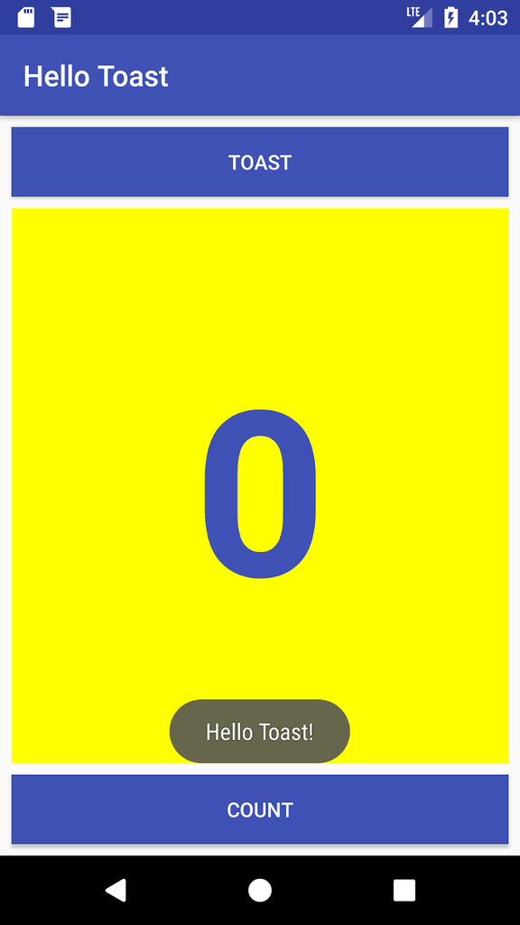

## Task 1: Create and explore a new project

#### 1.1 Create the Android Studio project

1. Start Android Studio and create a new project with the following parameters:

| Attribute | Value |
| --- | --- |
| Application Name | Hello Toast |
| Company Name | com.example.android (or your own domain) |
| Phone and Tablet Minimum SDK | API15: Android 4.0.3 IceCreamSandwich |
| Template | Empty Activity |
| Generate Layout file box | Selected |
| Google Analytics | Selected |

#### 1.2 Explore the layout editor

## Task 2: Add View elements in the layout editor

#### 2.1 Examine the element constraints

[figure not shown]

#### 2.2 Add a Button to the layout

#### 2.3 Add a second Button to the layout

## Task 3: Change UI element attributes

#### 3.1 Change the Button size

#### 3.2 Change the Button attributes

## Task 4: Add a TextEdit and set its attributes

#### 4.1 Add a TextView and constraints

- Image 1

[figure not shown]

- Image 2

[figure not shown]

#### 4.2 Set the TextView attributes

[figure not shown]

## Task 5: Edit the layout in XML

#### 5.1 Open the XML code for the layout

#### 5.2 Extract string resources

## Task 6: Add onClick handlers for the buttons

#### 6.1 Add the onClick attribute and handler to each Button

#### 6.2 Edit the Toast Button handler

#### 6.3 Edit the Count Button handler

### Hello Toast Project - Solution [here](https://github.com/google-developer-training/android-fundamentals-apps-v2/tree/master/HelloToast)

> for more experimenting try [xmlv!](https://labs.udacity.com/android-visualizer/) it's very handy

## Coding challenge

The HelloToast app looks fine when the device or emulator is vertically oriented. However, if you switch the device or emulator to horizontal orientation, the Count Button may overlap the TextView along the bottom as shown in the figure below.

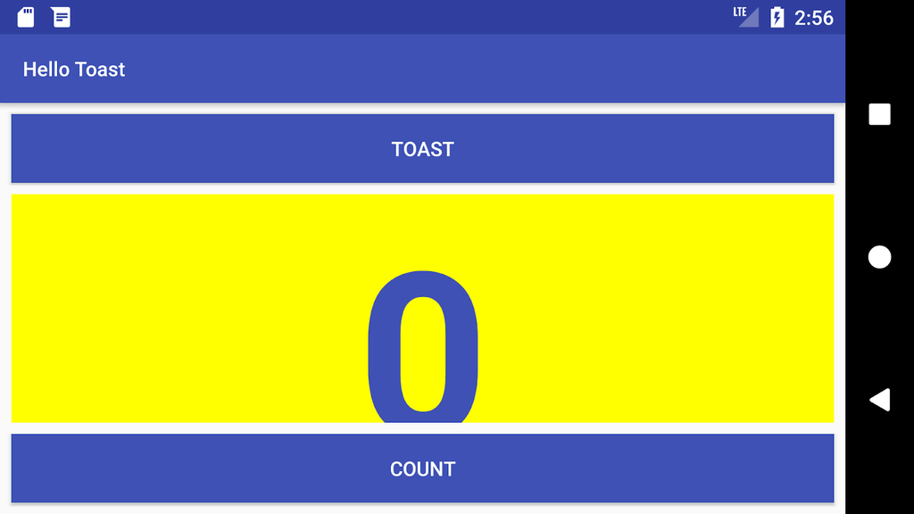

**Challenge: Change the layout so that it looks good in both horizontal and vertical orientations:**

- On your computer, make a copy of the HelloToast project folder and rename it to HelloToastChallenge.
- Open HelloToastChallenge in Android Studio and refactor it. (See Appendix: Utilities for instructions on copying and refactoring a project.)
- Change the layout so that the Toast Button and Count Button appear on the left side, as shown in the figure below. The TextView appears next to them, but only wide enough to show its contents. (Hint: Use wrap_content.)
- Run the app in both horizontal and vertical orientations.

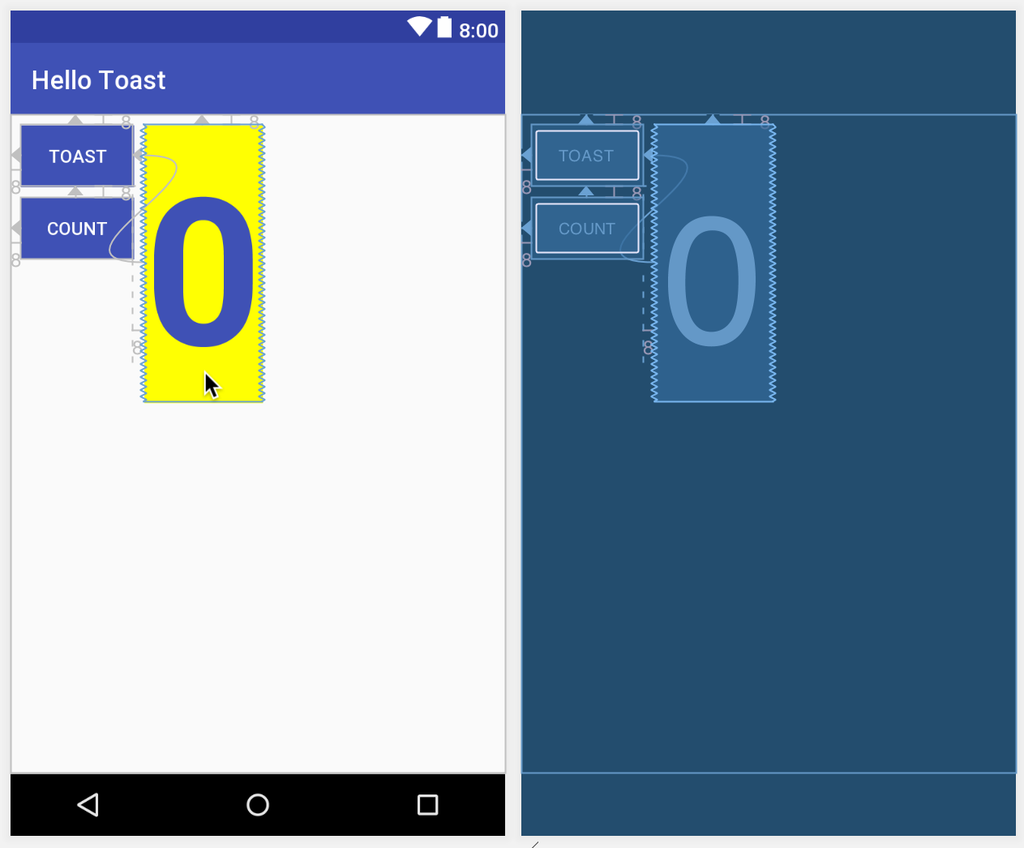

### [Challenge solution code](https://github.com/google-developer-training/android-fundamentals-apps-v2/tree/master/HelloToastChallenge)